# Income prediction project

## Data loading

This section is to import external libraries and read data

```python
# Import libraries
import pandas as pd
import numpy as np
import seaborn as sns
import matplotlib.pyplot as plt
import statsmodels.formula.api as smf
import statsmodels.api as sm
from scipy import stats
from sklearn.model_selection import KFold
from sklearn.metrics import mean_squared_error
```

```python
# Import training and test data
train_df = pd.read_csv('earnings_data_train.csv')
test_df = pd.read_csv('earnings_data_test.csv')
print(f'Size of train dataset: {train_df.shape}')
print(f'Size of test dataset: {test_df.shape}')
```

```
Size of train dataset: (14296, 12)
Size of test dataset: (3574, 11)
```

## Data cleaning

This section is to discuss some data quality checking and appropriate data cleaning

```python
train_df.head()
```

|  | ID | earnings | sex | age | mrd | educ | cworker | region | race | height | weight | occupation |
| --- | --- | --- | --- | --- | --- | --- | --- | --- | --- | --- | --- | --- |
| 0 | 0 | 84054.750000 | 1 | 51 | 1 | 18 | 1 | 2 | 1 | 67 | 165 | 1 |
| 1 | 1 | 17171.263670 | 0 | 38 | 5 | 1 | 1 | 4 | 3 | 60 | 140 | 13 |
| 2 | 2 | 8826.651367 | 0 | 39 | 6 | 10 | 1 | 2 | 2 | 63 | 150 | 8 |
| 3 | 3 | 28560.386720 | 1 | 35 | 5 | 14 | 1 | 4 | 1 | 67 | 144 | 3 |
| 4 | 4 | 20305.509770 | 1 | 53 | 6 | 8 | 1 | 3 | 3 | 70 | 185 | 12 |

```python
# Remove ID column
train_df = train_df.drop(columns=['ID'])
```

```python
# Remove rows with missing values
train_df.dropna(subset=['earnings'], inplace=True)
# Remove duplicate rows
train_df.drop_duplicates(inplace=True)
train_df.shape
```

```
(14291, 11)
```

```python
# Remove rows with missing values
test_df.dropna(inplace=True)
test_df.shape
```

```
(3574, 11)
```

### Data type treatment

```python
train_df.dtypes
```

```
earnings      float64
sex             int64
age             int64
mrd             int64
educ            int64
cworker         int64
region          int64
race            int64
height          int64
weight          int64
occupation      int64
dtype: object
```

Categorical variables: mrd, cworker, region, race, occupation need dummy variables.

```python
#Dummy variables for mrd with baseline = never married
train_df['married_spouse'] = np.where(train_df['mrd']==1,1,0)
train_df['married_no_spouse'] = np.where(train_df['mrd']==2,1,0)
train_df['widowed'] = np.where(train_df['mrd']==3,1,0)
train_df['divorced'] = np.where(train_df['mrd']==4,1,0)
train_df['separated'] = np.where(train_df['mrd']==5,1,0)
```

```python
# Dummy variables for cworker with baseline = self employed
train_df['private'] = np.where(train_df['cworker']==1,1,0)
train_df['federal'] = np.where(train_df['cworker']==2,1,0)
train_df['state'] = np.where(train_df['cworker']==3,1,0)
train_df['local'] = np.where(train_df['cworker']==4,1,0)
train_df['incorporated'] = np.where(train_df['cworker']==5,1,0)
```

```python
# Dummy variables for region with baseline = west
train_df['northeast'] = np.where(train_df['region']==1,1,0)
train_df['midwest'] = np.where(train_df['region']==2,1,0)
train_df['south'] = np.where(train_df['region']==3,1,0)
```

```python
# Dummy variables for race with baseline = other
train_df['non_hispanic_white'] = np.where(train_df['race']==1,1,0)
train_df['non_hispanic_black'] = np.where(train_df['race']==2,1,0)
train_df['hispanic'] = np.where(train_df['race']==3,1,0)
```

```python
# Dummy variables for occupation with baseline = laborer
train_df['exec_manager'] = np.where(train_df['occupation']==1,1,0)
train_df['professionals'] = np.where(train_df['occupation']==2,1,0)
train_df['technicians'] = np.where(train_df['occupation']==3,1,0)
train_df['sales'] = np.where(train_df['occupation']==4,1,0)
train_df['administrat'] = np.where(train_df['occupation']==5,1,0)
train_df['household'] = np.where(train_df['occupation']==6,1,0)
train_df['protective'] = np.where(train_df['occupation']==7,1,0)
train_df['other'] = np.where(train_df['occupation']==8,1,0)
train_df['farming'] = np.where(train_df['occupation']==9,1,0)
train_df['mechanics'] = np.where(train_df['occupation']==10,1,0)
train_df['construction'] = np.where(train_df['occupation']==11,1,0)
train_df['precision'] = np.where(train_df['occupation']==12,1,0)
train_df['machine'] = np.where(train_df['occupation']==13,1,0)
train_df['transport'] = np.where(train_df['occupation']==14,1,0)
```

```python
#Dummy variables for mrd with baseline = never married
test_df['married_spouse'] = np.where(test_df['mrd']==1,1,0)
test_df['married_no_spouse'] = np.where(test_df['mrd']==2,1,0)
test_df['widowed'] = np.where(test_df['mrd']==3,1,0)
test_df['divorced'] = np.where(test_df['mrd']==4,1,0)
test_df['separated'] = np.where(test_df['mrd']==5,1,0)

# Dummy variables for cworker with baseline = self employed
test_df['private'] = np.where(test_df['cworker']==1,1,0)
test_df['federal'] = np.where(test_df['cworker']==2,1,0)
test_df['state'] = np.where(test_df['cworker']==3,1,0)
test_df['local'] = np.where(test_df['cworker']==4,1,0)
test_df['incorporated'] = np.where(test_df['cworker']==5,1,0)

# Dummy variables for region with baseline = west
test_df['northeast'] = np.where(test_df['region']==1,1,0)
test_df['midwest'] = np.where(test_df['region']==2,1,0)
test_df['south'] = np.where(test_df['region']==3,1,0)

# Dummy variables for race with baseline = other
test_df['non_hispanic_white'] = np.where(test_df['race']==1,1,0)
test_df['non_hispanic_black'] = np.where(test_df['race']==2,1,0)
test_df['hispanic'] = np.where(test_df['race']==3,1,0)

# Dummy variables for occupation with baseline = laborer
test_df['exec_manager'] = np.where(test_df['occupation']==1,1,0)
test_df['professionals'] = np.where(test_df['occupation']==2,1,0)
test_df['technicians'] = np.where(test_df['occupation']==3,1,0)
test_df['sales'] = np.where(test_df['occupation']==4,1,0)
test_df['administrat'] = np.where(test_df['occupation']==5,1,0)
test_df['household'] = np.where(test_df['occupation']==6,1,0)
test_df['protective'] = np.where(test_df['occupation']==7,1,0)
test_df['other'] = np.where(test_df['occupation']==8,1,0)
test_df['farming'] = np.where(test_df['occupation']==9,1,0)
test_df['mechanics'] = np.where(test_df['occupation']==10,1,0)
test_df['construction'] = np.where(test_df['occupation']==11,1,0)
test_df['precision'] = np.where(test_df['occupation']==12,1,0)
test_df['machine'] = np.where(test_df['occupation']==13,1,0)
test_df['transport'] = np.where(test_df['occupation']==14,1,0)
```

## EDA and data transformation

- This section is to perform EDA to understand better the relationship between variables and statistical properties of all variables.
- Discuss some potential data transformation that will be potentially used to improve models'performance later. This section is to justify the motivation of applying any paricular data transformation later (if any).

### Earnings

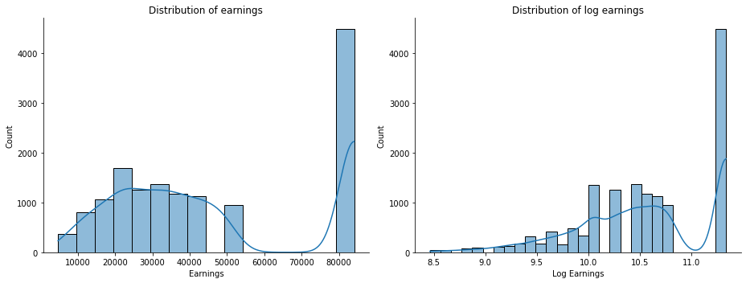

```python
train_df['log_earnings'] = np.log(train_df['earnings'])
fig, ax = plt.subplots(1,2,figsize=(13,5))

# Plot histogram of earnings
sns.histplot(x=train_df['earnings'], ax=ax[0], kde=True)
ax[0].set_title('Distribution of earnings', fontsize=12)
ax[0].set_xlabel('Earnings')

# Plot histogram of log earnings
sns.histplot(x=train_df['log_earnings'], ax=ax[1], kde=True)
ax[1].set_title('Distribution of log earnings', fontsize=12)
ax[1].set_xlabel('Log Earnings')

# Layout set up
sns.despine()
plt.tight_layout()
plt.show()
```

```python
# Summary statistics of earnings and log-earnings
table = train_df[['earnings', 'log_earnings']].describe()
table.loc['Skew', :]=train_df[['earnings', 'log_earnings']].skew()
table.loc['Kurt', :]=train_df[['earnings', 'log_earnings']].kurt()
table.round(2)
```

|  | earnings | log_earnings |
| --- | --- | --- |
| count | 14291.00 | 14291.00 |
| mean | 46938.28 | 10.56 |
| std | 26990.30 | 0.66 |
| min | 4726.39 | 8.46 |
| 25% | 23362.87 | 10.06 |
| 50% | 38925.34 | 10.57 |
| 75% | 84054.75 | 11.34 |
| max | 84054.75 | 11.34 |
| Skew | 0.39 | -0.47 |
| Kurt | -1.39 | -0.40 |

Log transformation on earnings results in a slight improvement in the kurtosis of the distribution, however, it is not significant enough to consider performing log transformation at this point.

### Earnings vs Age

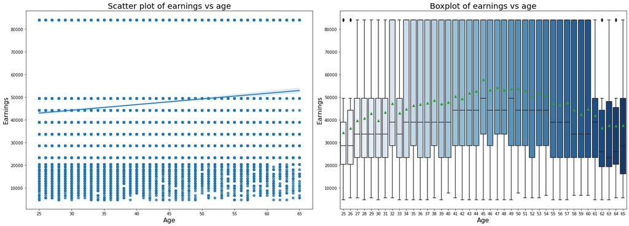

```python
fig, ax= plt.subplots(1,2, figsize=(22, 8))

# Scatter plot
sns.regplot(x=train_df['age'], y=train_df['earnings'], ax=ax[0])
ax[0].set_xlabel('Age', fontsize = 16)
ax[0].set_ylabel('Earnings', fontsize = 16)
ax[0].set_title('Scatter plot of earnings vs age', fontsize=20)

# Side-by-side boxplots
sns.boxplot(x=train_df['age'], y=train_df['earnings'], ax=ax[1], palette='Blues', showmeans=True)
ax[1].set_xlabel('Age', fontsize = 16)
ax[1].set_ylabel('Earnings', fontsize = 16)
ax[1].set_title('Boxplot of earnings vs age', fontsize=20)

plt.tight_layout()
plt.show()
```

```python
stats.pearsonr(train_df['age'], train_df['earnings'])
```

```
(0.09269175782307365, 1.2025544645188646e-28)
```

### Earnings vs Education

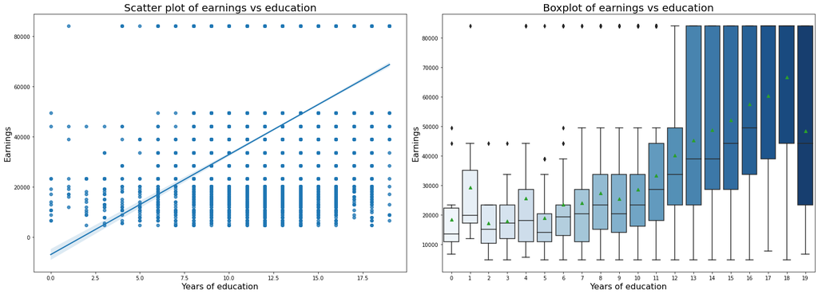

```python
fig, ax= plt.subplots(1,2, figsize=(22, 8))

# Scatter plot
sns.regplot(x=train_df['educ'], y=train_df['earnings'], ax=ax[0])
ax[0].set_xlabel('Years of education', fontsize = 16)
ax[0].set_ylabel('Earnings', fontsize = 16)
ax[0].set_title('Scatter plot of earnings vs education', fontsize=20)

# Side-by-side boxplots
sns.boxplot(x=train_df['educ'], y=train_df['earnings'], ax=ax[1], palette='Blues', showmeans=True)
ax[1].set_xlabel('Years of education', fontsize = 16)
ax[1].set_ylabel('Earnings', fontsize = 16)
ax[1].set_title('Boxplot of earnings vs education', fontsize=20)

plt.tight_layout()
plt.show()
```

```python
stats.pearsonr(train_df['educ'], train_df['earnings'])
```

```
(0.3883531530160633, 0.0)
```

### Earnings vs Height

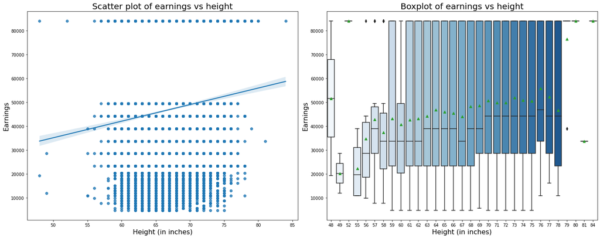

```python
fig, ax= plt.subplots(1,2, figsize=(20, 8))

# Scatter plot
sns.regplot(x=train_df['height'], y=train_df['earnings'], ax=ax[0])
ax[0].set_xlabel('Height (in inches)', fontsize=16)
ax[0].set_ylabel('Earnings', fontsize=16)
ax[0].set_title('Scatter plot of earnings vs height', fontsize=20)

# Side-by-side boxplots
sns.boxplot(x=train_df['height'], y=train_df['earnings'], ax=ax[1], palette='Blues', showmeans=True)
ax[1].set_xlabel('Height (in inches)', fontsize=16)
ax[1].set_ylabel('Earnings', fontsize=16)
ax[1].set_title('Boxplot of earnings vs height', fontsize=20)

plt.tight_layout()
plt.show()
```

```python
stats.pearsonr(train_df['height'], train_df['earnings'])
```

```
(0.10197497250591371, 2.3893966511010893e-34)
```

### Earnings vs Weight

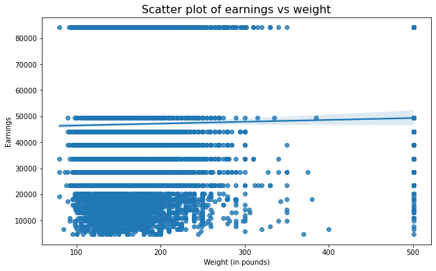

```python
# Scatter plot with regression line
plt.figure(figsize=(10,6))
sns.regplot(x=train_df['weight'], y=train_df['earnings'])
plt.xlabel('Weight (in pounds)')
plt.ylabel('Earnings')
plt.title('Scatter plot of earnings vs weight', fontsize=16)
plt.show()
```

```python
stats.pearsonr(train_df['weight'], train_df['earnings'])
```

```
(0.013476836257311322, 0.10717531422121825)
```

### Earnings vs Categorical predictors

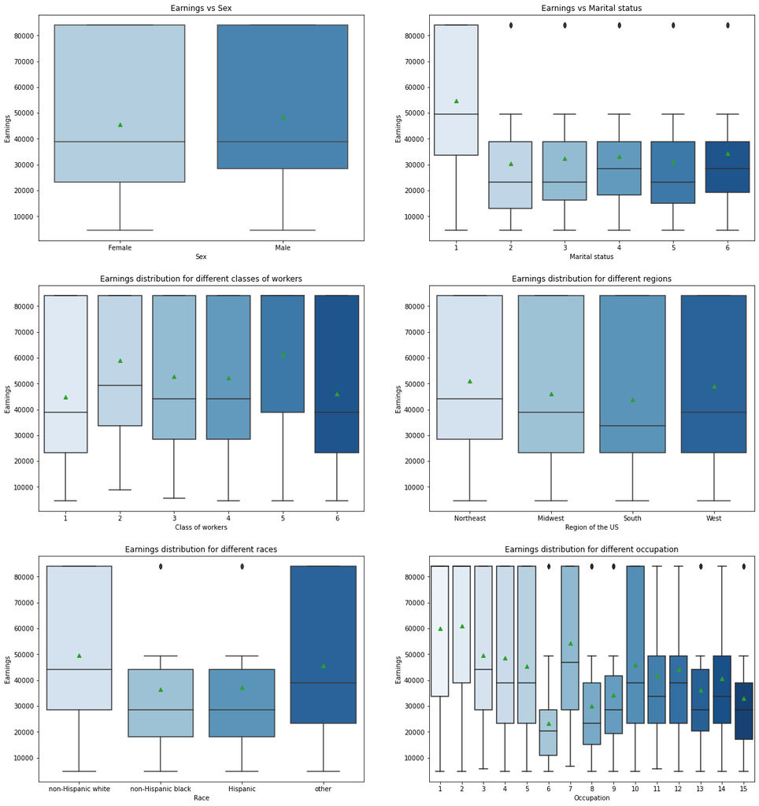

```python
# Side-by-side boxplots
fig, ax= plt.subplots(3,2, figsize=(20, 22))
sns.boxplot(x=train_df['sex'], y=train_df['earnings'], palette='Blues', ax=ax[0,0], showmeans=True)
ax[0,0].set_title('Earnings vs Sex')
ax[0,0].set_xlabel('Sex')
ax[0,0].set_ylabel('Earnings')
ax[0,0].set_xticks([0,1], ['Female', 'Male'])

sns.boxplot(x=train_df['mrd'], y=train_df['earnings'], palette='Blues', ax=ax[0,1], showmeans=True)
ax[0,1].set_title('Earnings vs Marital status')
ax[0,1].set_xlabel('Marital status')
ax[0,1].set_ylabel('Earnings')

sns.boxplot(x=train_df['cworker'], y=train_df['earnings'], palette='Blues', ax=ax[1,0],showmeans=True)
ax[1,0].set_title('Earnings distribution for different classes of workers')
ax[1,0].set_xlabel('Class of workers')
ax[1,0].set_ylabel('Earnings')

sns.boxplot(x=train_df['region'], y=train_df['earnings'], palette='Blues', ax=ax[1,1], showmeans=True)
ax[1,1].set_title('Earnings distribution for different regions')
ax[1,1].set_xticks([0,1,2,3], ['Northeast', 'Midwest', 'South', 'West'])
ax[1,1].set_xlabel('Region of the US')
ax[1,1].set_ylabel('Earnings')

sns.boxplot(x=train_df['race'], y=train_df['earnings'], palette='Blues', ax=ax[2,0], showmeans=True)
ax[2,0].set_title('Earnings distribution for different races')
ax[2,0].set_xlabel('Race')
ax[2,0].set_ylabel('Earnings')
ax[2,0].set_xticks([0,1,2,3], ['non-Hispanic white', 'non-Hispanic black', 'Hispanic', 'other'])

sns.boxplot(x=train_df['occupation'], y=train_df['earnings'], palette='Blues', ax=ax[2,1], showmeans=True)
ax[2,1].set_title('Earnings distribution for different occupation')
ax[2,1].set_xlabel('Occupation')
ax[2,1].set_ylabel('Earnings')
plt.show()
```

### Correlation matrix

```python
# Get correlation coefficients of numerical predictors
variables = ['log_earnings', 'earnings', 'age', 'educ', 'height', 'weight']
train_df[variables].corr().round(2)
```

|  | log_earnings | earnings | age | educ | height | weight |
| --- | --- | --- | --- | --- | --- | --- |
| log_earnings | 1.00 | 0.95 | 0.08 | 0.40 | 0.11 | 0.02 |
| earnings | 0.95 | 1.00 | 0.09 | 0.39 | 0.10 | 0.01 |
| age | 0.08 | 0.09 | 1.00 | -0.06 | -0.05 | 0.07 |
| educ | 0.40 | 0.39 | -0.06 | 1.00 | 0.11 | -0.02 |
| height | 0.11 | 0.10 | -0.05 | 0.11 | 1.00 | 0.38 |
| weight | 0.02 | 0.01 | 0.07 | -0.02 | 0.38 | 1.00 |

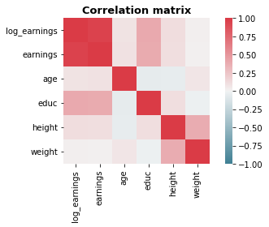

```python
# Visualise correlation matrix
fig, ax = plt.subplots()
cmap = sns.diverging_palette(220, 10, as_cmap=True)
sns.heatmap(train_df[variables].corr(), vmax=1, vmin=-1, center=0, square=True, ax=ax, cmap=cmap)
ax.set_title('Correlation matrix', fontweight='bold', fontsize=13)
plt.tight_layout()
plt.show()
```

## Model selection & prediction

- This section is to perform model selection between 3 candidate models and related discussion
- Make prediction for earnings on the test data

### Cross validation

```python
# Split train data into 10 folds for cross validation
n_folds = 10
kf = KFold(n_splits=n_folds, shuffle=True, random_state=6)
train_set, test_set = [], []

for train_index, test_index in kf.split(train_df):
    train = train_df.iloc[train_index]
    test = train_df.iloc[test_index]

    test_set.append(test)
    train_set.append(train)
```

### Full model

```python
formula = 'earnings ~ C(sex) + age + C(mrd) + C(cworker) + C(race) + C(region) + height + educ + weight + C(occupation)'
full_mod1 = smf.ols(formula=formula, data=train_df).fit()
print(full_mod1.summary())
```

```
                            OLS Regression Results
==============================================================================
Dep. Variable:               earnings   R-squared:                       0.366
Model:                            OLS   Adj. R-squared:                  0.364
Method:                 Least Squares   F-statistic:                     234.7
Date:                Thu, 02 Nov 2023   Prob (F-statistic):               0.00
Time:                        17:59:07   Log-Likelihood:            -1.6284e+05
No. Observations:               14291   AIC:                         3.258e+05
Df Residuals:                   14255   BIC:                         3.260e+05
Df Model:                          35
Covariance Type:            nonrobust
=======================================================================================
                          coef    std err          t      P>|t|      [0.025      0.975]
---------------------------------------------------------------------------------------
Intercept           -3326.7107   4627.712     -0.719      0.472   -1.24e+04    5744.208
C(sex)[T.1]           548.9144    558.340      0.983      0.326    -545.505    1643.334
C(mrd)[T.2]         -1.735e+04   1629.544    -10.648      0.000   -2.05e+04   -1.42e+04
C(mrd)[T.3]         -1.977e+04   1203.336    -16.430      0.000   -2.21e+04   -1.74e+04
C(mrd)[T.4]         -2.121e+04    530.018    -40.016      0.000   -2.22e+04   -2.02e+04
C(mrd)[T.5]         -1.829e+04   1044.509    -17.511      0.000   -2.03e+04   -1.62e+04
C(mrd)[T.6]         -2.061e+04    540.411    -38.146      0.000   -2.17e+04   -1.96e+04
C(cworker)[T.2]      7639.0629    971.233      7.865      0.000    5735.319    9542.807
C(cworker)[T.3]      -801.2098    830.525     -0.965      0.335   -2429.148     826.728
C(cworker)[T.4]      -508.8644    637.108     -0.799      0.424   -1757.678     739.950
C(cworker)[T.5]      5581.3707   1318.858      4.232      0.000    2996.237    8166.504
C(cworker)[T.6]      -961.4630    692.756     -1.388      0.165   -2319.354     396.428
C(race)[T.2]        -3999.0070    594.767     -6.724      0.000   -5164.827   -2833.187
C(race)[T.3]        -3346.2422    734.484     -4.556      0.000   -4785.927   -1906.557
C(race)[T.4]        -4681.3386    957.105     -4.891      0.000   -6557.390   -2805.287
C(region)[T.2]      -3683.9265    540.344     -6.818      0.000   -4743.071   -2624.782
C(region)[T.3]      -5243.9132    515.937    -10.164      0.000   -6255.218   -4232.609
C(region)[T.4]       -556.1404    570.821     -0.974      0.330   -1675.023     562.742
C(occupation)[T.2]  -2419.6124    721.184     -3.355      0.001   -3833.227   -1005.997
C(occupation)[T.3]  -6601.0611   1005.736     -6.563      0.000   -8572.434   -4629.688
C(occupation)[T.4]  -8739.5833    794.752    -10.997      0.000   -1.03e+04   -7181.766
C(occupation)[T.5]  -9070.9233    721.601    -12.571      0.000   -1.05e+04   -7656.492
C(occupation)[T.6]  -2.089e+04   2367.610     -8.823      0.000   -2.55e+04   -1.62e+04
C(occupation)[T.7]  -3083.7726   1428.147     -2.159      0.031   -5883.127    -284.418
C(occupation)[T.8]  -2.038e+04    813.299    -25.054      0.000    -2.2e+04   -1.88e+04
C(occupation)[T.9]   -1.76e+04   1451.428    -12.124      0.000   -2.04e+04   -1.48e+04
C(occupation)[T.10] -9228.9735   1221.963     -7.553      0.000   -1.16e+04   -6833.767
C(occupation)[T.11] -1.296e+04   1161.720    -11.154      0.000   -1.52e+04   -1.07e+04
C(occupation)[T.12] -1.025e+04   1324.319     -7.743      0.000   -1.28e+04   -7657.719
C(occupation)[T.13] -1.373e+04    924.252    -14.852      0.000   -1.55e+04   -1.19e+04
C(occupation)[T.14] -1.336e+04   1123.741    -11.885      0.000   -1.56e+04   -1.12e+04
C(occupation)[T.15] -1.668e+04   1267.077    -13.162      0.000   -1.92e+04   -1.42e+04
age                   251.7428     19.324     13.028      0.000     213.865     289.620
height                385.8737     69.194      5.577      0.000     250.244     521.503
educ                 2618.3377     88.233     29.675      0.000    2445.390    2791.286
weight                 -9.6062      3.858     -2.490      0.013     -17.168      -2.044
==============================================================================
Omnibus:                      457.806   Durbin-Watson:                   2.011
Prob(Omnibus):                  0.000   Jarque-Bera (JB):              400.579
Skew:                           0.349   Prob(JB):                     1.04e-87
Kurtosis:                       2.569   Cond. No.                     5.05e+03
==============================================================================

Notes:
[1] Standard Errors assume that the covariance matrix of the errors is correctly specified.
[2] The condition number is large, 5.05e+03. This might indicate that there are
strong multicollinearity or other numerical problems.
```

```python
formula = 'log_earnings ~ C(sex) + age + C(mrd) + C(cworker) + C(race) + C(region) + height + educ + weight + C(occupation)'
full_mod2 = smf.ols(formula=formula, data=train_df).fit()
print(full_mod2.summary())
```

```
                            OLS Regression Results
==============================================================================
Dep. Variable:           log_earnings   R-squared:                       0.399
Model:                            OLS   Adj. R-squared:                  0.398
Method:                 Least Squares   F-statistic:                     270.6
Date:                Thu, 02 Nov 2023   Prob (F-statistic):               0.00
Time:                        17:59:08   Log-Likelihood:                -10769.
No. Observations:               14291   AIC:                         2.161e+04
Df Residuals:                   14255   BIC:                         2.188e+04
Df Model:                          35
Covariance Type:            nonrobust
=======================================================================================
                          coef    std err          t      P>|t|      [0.025      0.975]
---------------------------------------------------------------------------------------
Intercept               9.2633      0.111     83.705      0.000       9.046       9.480
C(sex)[T.1]             0.0067      0.013      0.504      0.614      -0.019       0.033
C(mrd)[T.2]            -0.5042      0.039    -12.939      0.000      -0.581      -0.428
C(mrd)[T.3]            -0.5296      0.029    -18.403      0.000      -0.586      -0.473
C(mrd)[T.4]            -0.5344      0.013    -42.166      0.000      -0.559      -0.510
C(mrd)[T.5]            -0.5388      0.025    -21.571      0.000      -0.588      -0.490
C(mrd)[T.6]            -0.5293      0.013    -40.961      0.000      -0.555      -0.504
C(cworker)[T.2]         0.2029      0.023      8.736      0.000       0.157       0.248
C(cworker)[T.3]         0.0013      0.020      0.067      0.947      -0.038       0.040
C(cworker)[T.4]         0.0157      0.015      1.030      0.303      -0.014       0.046
C(cworker)[T.5]         0.1119      0.032      3.549      0.000       0.050       0.174
C(cworker)[T.6]        -0.0363      0.017     -2.189      0.029      -0.069      -0.004
C(race)[T.2]           -0.1327      0.014     -9.330      0.000      -0.161      -0.105
C(race)[T.3]           -0.1242      0.018     -7.072      0.000      -0.159      -0.090
C(race)[T.4]           -0.1199      0.023     -5.241      0.000      -0.165      -0.075
C(region)[T.2]         -0.0873      0.013     -6.753      0.000      -0.113      -0.062
C(region)[T.3]         -0.1397      0.012    -11.322      0.000      -0.164      -0.116
C(region)[T.4]         -0.0286      0.014     -2.093      0.036      -0.055      -0.002
C(occupation)[T.2]     -0.0654      0.017     -3.795      0.000      -0.099      -0.032
C(occupation)[T.3]     -0.1103      0.024     -4.587      0.000      -0.157      -0.063
C(occupation)[T.4]     -0.2042      0.019    -10.742      0.000      -0.241      -0.167
C(occupation)[T.5]     -0.1834      0.017    -10.630      0.000      -0.217      -0.150
C(occupation)[T.6]     -0.6397      0.057    -11.298      0.000      -0.751      -0.529
C(occupation)[T.7]     -0.0829      0.034     -2.429      0.015      -0.150      -0.016
C(occupation)[T.8]     -0.5229      0.019    -26.884      0.000      -0.561      -0.485
C(occupation)[T.9]     -0.4263      0.035    -12.282      0.000      -0.494      -0.358
C(occupation)[T.10]    -0.1799      0.029     -6.157      0.000      -0.237      -0.123
C(occupation)[T.11]    -0.2705      0.028     -9.736      0.000      -0.325      -0.216
C(occupation)[T.12]    -0.2029      0.032     -6.407      0.000      -0.265      -0.141
C(occupation)[T.13]    -0.3029      0.022    -13.705      0.000      -0.346      -0.260
C(occupation)[T.14]    -0.2863      0.027    -10.653      0.000      -0.339      -0.234
C(occupation)[T.15]    -0.4205      0.030    -13.879      0.000      -0.480      -0.361
age                     0.0052      0.000     11.342      0.000       0.004       0.006
height                  0.0108      0.002      6.550      0.000       0.008       0.014
educ                    0.0656      0.002     31.104      0.000       0.061       0.070
weight                 -0.0002   9.23e-05     -2.390      0.017      -0.000   -3.97e-05
==============================================================================
Omnibus:                      249.787   Durbin-Watson:                   2.001
Prob(Omnibus):                  0.000   Jarque-Bera (JB):              280.498
Skew:                          -0.287   Prob(JB):                     1.23e-61
Kurtosis:                       3.375   Cond. No.                     5.05e+03
==============================================================================

Notes:
[1] Standard Errors assume that the covariance matrix of the errors is correctly specified.
[2] The condition number is large, 5.05e+03. This might indicate that there are
strong multicollinearity or other numerical problems.
```

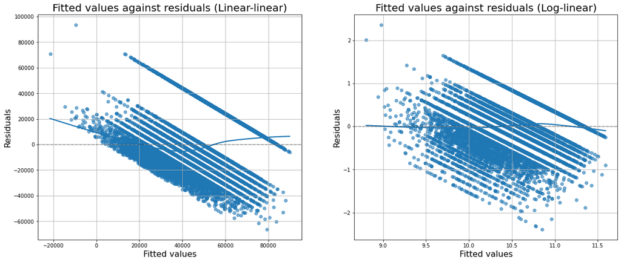

```python
# Compare residual plots of the two full models
fig, ax= plt.subplots(1, 2, figsize = (20,8))
sns.regplot(x=full_mod1.fittedvalues, y=full_mod1.resid, lowess=True, ax=ax[0], scatter_kws={'s': 35, 'alpha': .6})
ax[0].set_xlabel('Fitted values',  {'fontsize': 16})
ax[0].set_ylabel('Residuals', {'fontsize': 16})
ax[0].set_title('Fitted values against residuals (Linear-linear)', fontsize=20)
ax[0].axhline(color='Black', alpha=0.3, linestyle='--')
ax[0].grid()

sns.regplot(x=full_mod2.fittedvalues, y=full_mod2.resid, lowess=True, ax=ax[1], scatter_kws={'s': 35, 'alpha': .6})
ax[1].set_xlabel('Fitted values',  {'fontsize': 16})
ax[1].set_ylabel('Residuals', {'fontsize': 16})
ax[1].set_title('Fitted values against residuals (Log-linear)', fontsize=20)
ax[1].axhline(color='Black', alpha=0.3, linestyle='--')
ax[1].grid()

plt.show()
```

The LOESS line in the residual plot for the log-linear full model is relatively flat, which suggests that LSA 1 and 2 are well satisfied. Hence, log earnings is selected as the reponse variable for the MLR models.

```python
print(f"SER (Full model (Log-linear)): {full_mod2.mse_resid**0.5 :0.3f}")
```

```
SER (Full model (Log-linear)): 0.515
```

#### Log Earnings vs Numerical Predictors

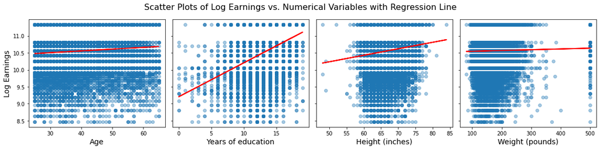

```python
variables = ['age', 'educ', 'height', 'weight']

fig, axes = plt.subplots(1, 4, figsize=(16, 4), sharey=True)
fig.suptitle('Scatter Plots of Log Earnings vs. Numerical Variables with Regression Line', fontsize=16)

for i, variable in enumerate(variables):
    ax = axes[i]

    x = train_df[variable]
    y = train_df['log_earnings']

    ax.scatter(x, y, alpha=0.4)
    ax.set_ylabel('')

    m, b = np.polyfit(x, y, 1)
    ax.plot(x, m * x + b, color='red', linewidth=2)  # Plot the regression line in red

axes[0].set_ylabel('Log Earnings', fontsize=14)
axes[0].set_xlabel('Age', fontsize=14)
axes[1].set_xlabel('Years of education', fontsize=14)
axes[2].set_xlabel('Height (inches)', fontsize=14)
axes[3].set_xlabel('Weight (pounds)', fontsize=14)

plt.tight_layout()
plt.show()
```

The relationships between log earnings and the numerical predictors are very similar to those of earnings.

#### Cross validation

```python
model1 = []
sumsq_rmse = 0
formula = 'log_earnings ~ C(sex) + age + C(mrd) + C(cworker) + C(race) + C(region) + height + educ + weight + C(occupation)'

for i in range(n_folds):
    mod = smf.ols(formula=formula, data=train_set[i]).fit()
    model1.append(mod)
    pred = np.exp(mod.predict(test_set[i]))
    print(f"Fold {i+1}:")
    print(f"Adj. R-squared: {mod.rsquared_adj: 0.3f}")
    rmse = np.sqrt(mean_squared_error(test_set[i]['earnings'], pred))
    sumsq_rmse += rmse**2
    print(f"RMSE: {rmse:.3f}")
    print("-----------------")

mean_r2 = np.mean([mod.rsquared_adj for mod in model1])
print(f'Average adj. R-squared: {mean_r2:.3f}')
rmse_cv = np.sqrt(sumsq_rmse/n_folds)
print(f'RMS cross validation error: {rmse_cv:.3f}')
```

```
Fold 1:
Adj. R-squared:  0.398
RMSE: 22119.998
-----------------
Fold 2:
Adj. R-squared:  0.401
RMSE: 22924.330
-----------------
Fold 3:
Adj. R-squared:  0.397
RMSE: 21872.060
-----------------
Fold 4:
Adj. R-squared:  0.396
RMSE: 23036.891
-----------------
Fold 5:
Adj. R-squared:  0.400
RMSE: 22233.085
-----------------
Fold 6:
Adj. R-squared:  0.396
RMSE: 22219.338
-----------------
Fold 7:
Adj. R-squared:  0.397
RMSE: 22205.592
-----------------
Fold 8:
Adj. R-squared:  0.396
RMSE: 21831.652
-----------------
Fold 9:
Adj. R-squared:  0.394
RMSE: 21818.419
-----------------
Fold 10:
Adj. R-squared:  0.401
RMSE: 22105.598
-----------------
Average adj. R-squared: 0.398
RMS cross validation error: 22240.332
```

```python
# Calculate VIFs for numerical predictors
features = train_df[['age', 'educ', 'weight', 'height']]
features = sm.add_constant(features)
from statsmodels.stats.outliers_influence import variance_inflation_factor
vif = []
for i in range(4):
    vif.append(variance_inflation_factor(features.values, i+1))

print(vif)
print(f"Average VIF: {sum(vif)/4 :0.3f}")
```

```
[1.0141958186315274, 1.0185465427285545, 1.1794878147823638, 1.1903097108159844]
Average VIF: 1.101
```

### Reduced model without interaction terms

#### Forward selection

```python
def forward_selected(data, response):
    """Linear model designed by forward selection.

    Parameters:
    -----------
    data : pandas DataFrame with all possible predictors and response

    response: string, name of response column in data

    Returns:
    --------
    model: an "optimal" fitted statsmodels linear model
           with an intercept
           selected by forward selection
           evaluated by adjusted R-squared
    """
    categorical = ['sex', 'mrd', 'cworker', 'race', 'region', 'occupation']
    remaining = set(data.columns)
    remaining.remove(response)
    selected = []
    current_score, best_new_score = 0.0, 0.0
    while remaining and current_score == best_new_score:
        scores_with_candidates = []
        for candidate in remaining:
            predictor = candidate
            if candidate in categorical:
                predictor = 'C(' + candidate + ')'
            formula = "{} ~ {} + 1".format(response,
                                           ' + '.join(selected + [predictor]))
            score = smf.ols(formula, data).fit().rsquared_adj
            scores_with_candidates.append((score, candidate))
        scores_with_candidates.sort()
        best_new_score, best_candidate = scores_with_candidates.pop()
        if current_score < best_new_score:
            #print("adding %s increases adj_r2 from %f to %f" %(best_candidate, current_score, best_new_score))
            remaining.remove(best_candidate)
            if best_candidate in categorical:
                best_candidate = 'C(' + best_candidate + ')'
            selected.append(best_candidate)
            current_score = best_new_score
    formula = "{} ~ {} + 1".format(response,
                                   ' + '.join(selected))
    model = smf.ols(formula, data).fit()
    print(formula)
    return model
```

```python
# Forward selection on 10 folds
for i in range(n_folds):
    print(f'Fold {i+1}: ')
    data = train_set[i][['log_earnings', 'age', 'educ', 'height', 'weight', 'sex', 'mrd', 'cworker', 'race', 'region', 'occupation']]
    model_fwd = forward_selected(data, 'log_earnings')
    print(f'Adjusted R-squared: {model_fwd.rsquared_adj:.3f}')
    pred = np.exp(model_fwd.predict(test_set[i]))
    rmse = np.sqrt(mean_squared_error(test_set[i]['earnings'], pred))
    print(f'RMSE: {rmse:.3f}')
    print('---------------')
```

```
Fold 1:
log_earnings ~ C(mrd) + educ + C(occupation) + C(race) + C(region) + age + C(cworker) + height + weight + 1
Adjusted R-squared: 0.398
RMSE: 22120.094
---------------
Fold 2:
log_earnings ~ C(occupation) + C(mrd) + educ + C(race) + C(region) + age + C(cworker) + height + weight + 1
Adjusted R-squared: 0.401
RMSE: 22922.152
---------------
Fold 3:
log_earnings ~ C(mrd) + educ + C(occupation) + C(race) + C(region) + C(cworker) + age + height + weight + 1
Adjusted R-squared: 0.397
RMSE: 21871.208
---------------
Fold 4:
log_earnings ~ C(mrd) + educ + C(occupation) + C(race) + C(region) + age + C(cworker) + height + weight + 1
Adjusted R-squared: 0.396
RMSE: 23028.682
---------------
Fold 5:
log_earnings ~ C(mrd) + educ + C(occupation) + C(race) + C(region) + age + C(cworker) + height + weight + 1
Adjusted R-squared: 0.400
RMSE: 22233.382
---------------
Fold 6:
log_earnings ~ C(mrd) + educ + C(occupation) + C(race) + age + C(region) + C(cworker) + height + weight + 1
Adjusted R-squared: 0.396
RMSE: 22219.701
---------------
Fold 7:
log_earnings ~ C(occupation) + C(mrd) + educ + C(race) + C(region) + age + C(cworker) + height + weight + 1
Adjusted R-squared: 0.397
RMSE: 22205.213
---------------
Fold 8:
log_earnings ~ C(mrd) + educ + C(occupation) + C(race) + C(region) + age + C(cworker) + height + weight + 1
Adjusted R-squared: 0.396
RMSE: 21829.522
---------------
Fold 9:
log_earnings ~ C(mrd) + educ + C(occupation) + C(race) + C(region) + age + C(cworker) + height + weight + 1
Adjusted R-squared: 0.394
RMSE: 21809.413
---------------
Fold 10:
log_earnings ~ C(mrd) + educ + C(occupation) + C(race) + age + C(region) + C(cworker) + height + weight + 1
Adjusted R-squared: 0.401
RMSE: 22098.791
---------------
```

#### Backward selection

```python
def backward_selected(data, response):
    """Linear model designed by backward selection.

    Parameters:
    -----------
    data : pandas DataFrame with all possible predictors and response

    response: string, name of response column in data

    Returns:
    --------
    model: an "optimal" fitted statsmodels linear model
           with an intercept
           selected by backward selection
           evaluated by adjusted R-squared
    """
    categorical = ['sex', 'mrd', 'cworker', 'race', 'region', 'occupation']
    predictors = list(data.columns)
    for i in range(len(predictors)):
        if predictors[i] in categorical:
            predictors[i] = 'C(' + predictors[i] + ')'
    remaining = set(predictors)
    remaining.remove(response)
    formula = "{} ~ {} + 1".format(response,' + '.join(remaining))
    current_score = smf.ols(formula, data).fit().rsquared_adj
    print("adj_r2 if all variables included: %f" %current_score)
    best_new_score = current_score
    while remaining and current_score == best_new_score:
        scores_with_candidates = []
        for candidate in remaining:
            formula = "{} ~ {} + 1".format(response,
                                           ' + '.join(remaining^{candidate}))
            score = smf.ols(formula, data).fit().rsquared_adj
            scores_with_candidates.append((score, candidate))
        scores_with_candidates.sort()
        best_new_score, best_candidate = scores_with_candidates.pop()
        if current_score < best_new_score:
            #print("deleting %s increases adj_r2 from %f to %f" %(best_candidate, current_score, best_new_score))
            remaining.remove(best_candidate)
            current_score = best_new_score
    formula = "{} ~ {} + 1".format(response,
                                   ' + '.join(remaining))
    model = smf.ols(formula, data).fit()
    print(formula)
    return model
```

```python
# Backward selection on 10 folds
for i in range(n_folds):
    print(f'Fold {i+1}: ')
    data = train_set[i][['log_earnings', 'age', 'educ', 'height', 'weight', 'sex', 'mrd', 'cworker', 'race', 'region', 'occupation']]
    model_bwd = backward_selected(data, 'log_earnings')
    print(f'Adjusted R-squared: {model_bwd.rsquared_adj:.3f}')
    pred = np.exp(model_bwd.predict(test_set[i]))
    rmse = np.sqrt(mean_squared_error(test_set[i]['earnings'], pred))
    print(f'RMSE: {rmse:.3f}')
    print('---------------')
```

```
Fold 1:
adj_r2 if all variables included: 0.398431
log_earnings ~ C(cworker) + C(race) + C(occupation) + C(mrd) + C(region) + educ + height + age + weight + 1
Adjusted R-squared: 0.398
RMSE: 22120.094
---------------
Fold 2:
adj_r2 if all variables included: 0.401315
log_earnings ~ C(cworker) + C(race) + C(occupation) + C(mrd) + C(region) + educ + height + age + weight + 1
Adjusted R-squared: 0.401
RMSE: 22922.152
---------------
Fold 3:
adj_r2 if all variables included: 0.397345
log_earnings ~ C(cworker) + C(race) + C(occupation) + C(mrd) + C(region) + educ + height + age + weight + 1
Adjusted R-squared: 0.397
RMSE: 21871.208
---------------
Fold 4:
adj_r2 if all variables included: 0.396437
log_earnings ~ C(cworker) + C(race) + C(occupation) + C(mrd) + C(region) + educ + height + age + weight + 1
Adjusted R-squared: 0.396
RMSE: 23028.682
---------------
Fold 5:
adj_r2 if all variables included: 0.399592
log_earnings ~ C(cworker) + C(race) + C(occupation) + C(mrd) + C(region) + educ + height + age + weight + 1
Adjusted R-squared: 0.400
RMSE: 22233.382
---------------
Fold 6:
adj_r2 if all variables included: 0.396188
log_earnings ~ C(cworker) + C(race) + C(occupation) + C(mrd) + C(region) + educ + height + age + weight + 1
Adjusted R-squared: 0.396
RMSE: 22219.701
---------------
Fold 7:
adj_r2 if all variables included: 0.397017
log_earnings ~ C(cworker) + C(race) + C(occupation) + C(mrd) + C(region) + educ + height + age + weight + 1
Adjusted R-squared: 0.397
RMSE: 22205.213
---------------
Fold 8:
adj_r2 if all variables included: 0.395877
log_earnings ~ C(cworker) + C(race) + C(occupation) + C(mrd) + C(region) + educ + height + age + weight + 1
Adjusted R-squared: 0.396
RMSE: 21829.522
---------------
Fold 9:
adj_r2 if all variables included: 0.394101
log_earnings ~ C(cworker) + C(race) + C(occupation) + C(mrd) + C(region) + educ + height + age + weight + 1
Adjusted R-squared: 0.394
RMSE: 21809.413
---------------
Fold 10:
adj_r2 if all variables included: 0.400958
log_earnings ~ C(cworker) + C(race) + C(occupation) + C(mrd) + C(region) + educ + height + age + weight + 1
Adjusted R-squared: 0.401
RMSE: 22098.791
---------------
```

For both backwards & forwards selection, variable `sex` was removed in all of the 10 folds. Hence, we will drop `sex` from the full model.

```python
# Cross validation for reduced model without interaction terms
model2 = []
sumsq_rmse = 0
formula = 'log_earnings ~ age + C(mrd) + C(cworker) + C(race) + C(region) + height + educ + weight + C(occupation)'

for i in range(n_folds):
    mod = smf.ols(formula=formula, data=train_set[i]).fit()
    model2.append(mod)
    pred = np.exp(mod.predict(test_set[i]))
    print(f"Fold {i+1}:")
    print(f"Adj. R-squared: {mod.rsquared_adj: 0.3f}")
    rmse = np.sqrt(mean_squared_error(test_set[i]['earnings'], pred))
    sumsq_rmse += rmse**2
    print(f"RMSE: {rmse:.3f}")
    print("-----------------")

mean_r2 = np.mean([mod.rsquared_adj for mod in model2])
print(f'Average adj. R-squared: {mean_r2:.3f}')
rmse_cv = np.sqrt(sumsq_rmse/n_folds)
print(f'RMS cross validation error: {rmse_cv:.3f}')
```

```
Fold 1:
Adj. R-squared:  0.398
RMSE: 22120.094
-----------------
Fold 2:
Adj. R-squared:  0.401
RMSE: 22922.152
-----------------
Fold 3:
Adj. R-squared:  0.397
RMSE: 21871.208
-----------------
Fold 4:
Adj. R-squared:  0.396
RMSE: 23028.682
-----------------
Fold 5:
Adj. R-squared:  0.400
RMSE: 22233.382
-----------------
Fold 6:
Adj. R-squared:  0.396
RMSE: 22219.701
-----------------
Fold 7:
Adj. R-squared:  0.397
RMSE: 22205.213
-----------------
Fold 8:
Adj. R-squared:  0.396
RMSE: 21829.522
-----------------
Fold 9:
Adj. R-squared:  0.394
RMSE: 21809.413
-----------------
Fold 10:
Adj. R-squared:  0.401
RMSE: 22098.791
-----------------
Average adj. R-squared: 0.398
RMS cross validation error: 22237.443
```

```python
# Fit model to train dataset
mod2 = smf.ols(formula=formula, data=train_df).fit()
print(mod2.summary())
```

```
                            OLS Regression Results
==============================================================================
Dep. Variable:           log_earnings   R-squared:                       0.399
Model:                            OLS   Adj. R-squared:                  0.398
Method:                 Least Squares   F-statistic:                     278.6
Date:                Thu, 02 Nov 2023   Prob (F-statistic):               0.00
Time:                        18:01:31   Log-Likelihood:                -10769.
No. Observations:               14291   AIC:                         2.161e+04
Df Residuals:                   14256   BIC:                         2.187e+04
Df Model:                          34
Covariance Type:            nonrobust
=======================================================================================
                          coef    std err          t      P>|t|      [0.025      0.975]
---------------------------------------------------------------------------------------
Intercept               9.2291      0.087    105.681      0.000       9.058       9.400
C(mrd)[T.2]            -0.5038      0.039    -12.932      0.000      -0.580      -0.427
C(mrd)[T.3]            -0.5305      0.029    -18.476      0.000      -0.587      -0.474
C(mrd)[T.4]            -0.5347      0.013    -42.222      0.000      -0.560      -0.510
C(mrd)[T.5]            -0.5390      0.025    -21.580      0.000      -0.588      -0.490
C(mrd)[T.6]            -0.5290      0.013    -40.984      0.000      -0.554      -0.504
C(cworker)[T.2]         0.2033      0.023      8.756      0.000       0.158       0.249
C(cworker)[T.3]         0.0013      0.020      0.065      0.948      -0.038       0.040
C(cworker)[T.4]         0.0154      0.015      1.014      0.311      -0.014       0.045
C(cworker)[T.5]         0.1127      0.032      3.576      0.000       0.051       0.174
C(cworker)[T.6]        -0.0363      0.017     -2.189      0.029      -0.069      -0.004
C(race)[T.2]           -0.1329      0.014     -9.347      0.000      -0.161      -0.105
C(race)[T.3]           -0.1229      0.017     -7.075      0.000      -0.157      -0.089
C(race)[T.4]           -0.1183      0.023     -5.222      0.000      -0.163      -0.074
C(region)[T.2]         -0.0875      0.013     -6.775      0.000      -0.113      -0.062
C(region)[T.3]         -0.1399      0.012    -11.340      0.000      -0.164      -0.116
C(region)[T.4]         -0.0287      0.014     -2.100      0.036      -0.055      -0.002
C(occupation)[T.2]     -0.0654      0.017     -3.791      0.000      -0.099      -0.032
C(occupation)[T.3]     -0.1100      0.024     -4.574      0.000      -0.157      -0.063
C(occupation)[T.4]     -0.2037      0.019    -10.731      0.000      -0.241      -0.167
C(occupation)[T.5]     -0.1839      0.017    -10.678      0.000      -0.218      -0.150
C(occupation)[T.6]     -0.6406      0.057    -11.320      0.000      -0.752      -0.530
C(occupation)[T.7]     -0.0812      0.034     -2.390      0.017      -0.148      -0.015
C(occupation)[T.8]     -0.5229      0.019    -26.887      0.000      -0.561      -0.485
C(occupation)[T.9]     -0.4246      0.035    -12.291      0.000      -0.492      -0.357
C(occupation)[T.10]    -0.1778      0.029     -6.150      0.000      -0.234      -0.121
C(occupation)[T.11]    -0.2681      0.027     -9.791      0.000      -0.322      -0.214
C(occupation)[T.12]    -0.2016      0.032     -6.388      0.000      -0.263      -0.140
C(occupation)[T.13]    -0.3018      0.022    -13.728      0.000      -0.345      -0.259
C(occupation)[T.14]    -0.2845      0.027    -10.682      0.000      -0.337      -0.232
C(occupation)[T.15]    -0.4190      0.030    -13.901      0.000      -0.478      -0.360
age                     0.0053      0.000     11.408      0.000       0.004       0.006
height                  0.0114      0.001      8.943      0.000       0.009       0.014
educ                    0.0656      0.002     31.110      0.000       0.062       0.070
weight                 -0.0002   9.22e-05     -2.373      0.018      -0.000   -3.81e-05
==============================================================================
Omnibus:                      249.082   Durbin-Watson:                   2.001
Prob(Omnibus):                  0.000   Jarque-Bera (JB):              279.656
Skew:                          -0.287   Prob(JB):                     1.88e-61
Kurtosis:                       3.375   Cond. No.                     3.99e+03
==============================================================================

Notes:
[1] Standard Errors assume that the covariance matrix of the errors is correctly specified.
[2] The condition number is large, 3.99e+03. This might indicate that there are
strong multicollinearity or other numerical problems.
```

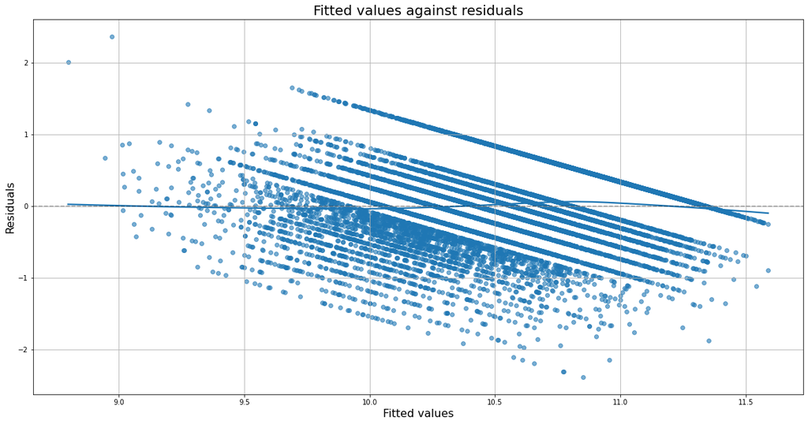

```python
residuals = mod2.resid
fitted =  mod2.fittedvalues

# Residual plot of reduced model without interaction terms
fig, ax= plt.subplots(figsize = (20,10))
sns.regplot(x=fitted, y=residuals, lowess=True, ax=ax, scatter_kws={'s': 35, 'alpha': .6})
ax.set_xlabel('Fitted values',  {'fontsize': 16})
ax.set_ylabel('Residuals', {'fontsize': 16})
ax.set_title('Fitted values against residuals', fontsize=20)
plt.axhline(color='Black', alpha=0.3, linestyle='--')
plt.grid()
plt.show()
```

```python
print(f"SER (Model 3): {mod2.mse_resid**0.5 :0.3f}")
```

```
SER (Model 3): 0.515
```

### Reduced model with interaction terms

Selected interaction terms are age:cworker, educ:region, educ:cworker, educ:mrd, educ:occupation, height:occupation, weight:occupation

```python
mrd = ['married_spouse', 'married_no_spouse', 'widowed', 'divorced', 'separated']
region = ['northeast', 'midwest', 'south']
cworker = ['federal', 'private', 'local', 'state', 'incorporated']
race = ['non_hispanic_white', 'non_hispanic_black', 'hispanic']
occupation = ['exec_manager', 'professionals', 'technicians', 'sales', 'administrat', 'household', 'protective', 'other', 'farming', 'mechanics', 'construction', 'precision', 'machine', 'transport']
age_inter = cworker
educ_inter = mrd + occupation + region + cworker
cat_inter = '+'.join(mrd + cworker + occupation + region + race)
formula = 'log_earnings ~ age + educ + height + weight + ' + cat_inter

# Interactions with age
for var in age_inter:
    name =  'age_' + var
    train_df[name] = train_df['age'] * train_df[var]
    test_df[name] = test_df['age'] * test_df[var]
    formula += ' + ' + name

# Interaction with educ
for var in educ_inter:
    name =  'educ_' + var
    train_df[name] = train_df['educ'] * train_df[var]
    test_df[name] = test_df['educ'] * test_df[var]
    formula += ' + ' + name

for var in occupation:
    name1 = 'height_' + var
    train_df[name1] = train_df['height'] * train_df[var]
    test_df[name1] = test_df['height'] * test_df[var]
    name2 = 'weight_' + var
    train_df[name2] = train_df['weight'] * train_df[var]
    test_df[name2] = test_df['weight'] * test_df[var]
    formula += ' + ' + name1 + ' + ' + name2
    formula += ' + ' + name1
```

```python
train_set, test_set = [], []

for train_index, test_index in kf.split(train_df):
    train = train_df.iloc[train_index]
    test = train_df.iloc[test_index]

    test_set.append(test)
    train_set.append(train)
```

```python
# Cross validation for reduced model with interaction terms
model3 = []
sumsq_rmse = 0
for i in range(n_folds):
    mod = smf.ols(formula=formula, data=train_set[i]).fit()
    model3.append(mod)
    pred = np.exp(mod.predict(test_set[i]))
    print(f"Fold {i+1}:")
    print(f"Adj. R-squared: {mod.rsquared_adj: 0.3f}")
    rmse = np.sqrt(mean_squared_error(test_set[i]['earnings'], pred))
    sumsq_rmse += rmse**2
    print(f"RMSE: {rmse:.3f}")
    print("-----------------")

mean_r2 = np.mean([mod.rsquared_adj for mod in model3])
print(f'Average adj. R-squared: {mean_r2:.3f}')
rmse_cv = np.sqrt(sumsq_rmse/n_folds)
print(f'RMS cross validation error: {rmse_cv:.3f}')
```

```
Fold 1:
Adj. R-squared:  0.404
RMSE: 21847.688
-----------------
Fold 2:
Adj. R-squared:  0.409
RMSE: 22834.940
-----------------
Fold 3:
Adj. R-squared:  0.405
RMSE: 21840.171
-----------------
Fold 4:
Adj. R-squared:  0.404
RMSE: 23038.979
-----------------
Fold 5:
Adj. R-squared:  0.407
RMSE: 22112.892
-----------------
Fold 6:
Adj. R-squared:  0.403
RMSE: 22074.577
-----------------
Fold 7:
Adj. R-squared:  0.403
RMSE: 22066.733
-----------------
Fold 8:
Adj. R-squared:  0.403
RMSE: 21873.861
-----------------
Fold 9:
Adj. R-squared:  0.401
RMSE: 21692.395
-----------------
Fold 10:
Adj. R-squared:  0.407
RMSE: 22055.944
-----------------
Average adj. R-squared: 0.405
RMS cross validation error: 22147.780
```

```python
# Fit model on train dataset
mod3 = smf.ols(formula=formula, data=train_df).fit()
print(mod3.summary())
```

```
                            OLS Regression Results
==============================================================================
Dep. Variable:           log_earnings   R-squared:                       0.408
Model:                            OLS   Adj. R-squared:                  0.404
Method:                 Least Squares   F-statistic:                     104.2
Date:                Thu, 02 Nov 2023   Prob (F-statistic):               0.00
Time:                        18:01:39   Log-Likelihood:                -10659.
No. Observations:               14291   AIC:                         2.151e+04
Df Residuals:                   14196   BIC:                         2.223e+04
Df Model:                          94
Covariance Type:            nonrobust
==========================================================================================
                             coef    std err          t      P>|t|      [0.025      0.975]
------------------------------------------------------------------------------------------
Intercept                  8.5965      0.462     18.595      0.000       7.690       9.503
age                       -0.0018      0.001     -1.211      0.226      -0.005       0.001
educ                       0.0576      0.013      4.290      0.000       0.031       0.084
height                     0.0093      0.007      1.289      0.197      -0.005       0.024
weight                     0.0001      0.001      0.151      0.880      -0.001       0.001
married_spouse             0.4976      0.068      7.274      0.000       0.363       0.632
married_no_spouse          0.1162      0.137      0.846      0.397      -0.153       0.385
widowed                   -0.3610      0.138     -2.614      0.009      -0.632      -0.090
divorced                  -0.1711      0.090     -1.910      0.056      -0.347       0.005
separated                 -0.2679      0.129     -2.069      0.039      -0.522      -0.014
federal                    0.0577      0.208      0.277      0.782      -0.350       0.466
private                   -0.3558      0.111     -3.198      0.001      -0.574      -0.138
local                     -0.0944      0.145     -0.650      0.515      -0.379       0.190
state                     -0.0204      0.168     -0.121      0.904      -0.350       0.309
incorporated              -0.0025      0.242     -0.010      0.992      -0.476       0.471
exec_manager               0.9604      0.504      1.906      0.057      -0.027       1.948
professionals              0.5034      0.485      1.037      0.300      -0.448       1.455
technicians               -0.0224      0.577     -0.039      0.969      -1.152       1.108
sales                     -1.0190      0.498     -2.048      0.041      -1.994      -0.044
administrat                0.7024      0.489      1.435      0.151      -0.257       1.662
household                  0.8339      1.396      0.597      0.550      -1.902       3.570
protective                -0.0196      0.841     -0.023      0.981      -1.667       1.628
other                      0.4137      0.499      0.829      0.407      -0.564       1.391
farming                   -0.7891      0.693     -1.139      0.255      -2.148       0.569
mechanics                  0.8947      0.741      1.207      0.227      -0.558       2.347
construction              -0.3779      0.692     -0.546      0.585      -1.734       0.978
```

[output cut: 65 more lines]

```
height_machine             0.0171      0.008      2.027      0.043       0.001       0.034
weight_machine            -0.0002      0.001     -0.282      0.778      -0.002       0.001
height_transport           0.0164      0.010      1.610      0.107      -0.004       0.036
weight_transport           0.0001      0.001      0.165      0.869      -0.002       0.002
==============================================================================
Omnibus:                      271.530   Durbin-Watson:                   2.003
Prob(Omnibus):                  0.000   Jarque-Bera (JB):              313.185
Skew:                          -0.293   Prob(JB):                     9.84e-69
Kurtosis:                       3.429   Cond. No.                     8.79e+04
==============================================================================

Notes:
[1] Standard Errors assume that the covariance matrix of the errors is correctly specified.
[2] The condition number is large, 8.79e+04. This might indicate that there are
strong multicollinearity or other numerical problems.
```

#### F-test for interaction terms

```python
interaction = ['age:cworker', 'educ:cworker', 'educ:region', 'educ:mrd', 'educ:occupation', 'height:occupation', 'weight:occupation']
f_stat, p_val = [], []
```

```python
# age:cworker interaction
hypotheses = '(age_federal = 0), (age_private = 0), (age_local = 0), (age_state = 0), (age_incorporated = 0)'
f_test = mod3.f_test(hypotheses)
f_stat.append(round(f_test.fvalue,3))
p_val.append(round(f_test.pvalue,3))
```

```python
# educ:cworker interaction
hypotheses = '(educ_federal = 0), (educ_private = 0), (educ_local = 0), (educ_state = 0), (educ_incorporated = 0)'
f_test = mod3.f_test(hypotheses)
f_stat.append(round(f_test.fvalue,3))
p_val.append(round(f_test.pvalue,3))
```

```python
# educ:region interaction
hypotheses = '(educ_northeast = 0), (educ_midwest = 0), (educ_south = 0)'
f_test = mod3.f_test(hypotheses)
f_stat.append(round(f_test.fvalue,3))
p_val.append(round(f_test.pvalue,3))
```

```python
# educ:mrd interaction
hypotheses = '(educ_married_spouse = 0), (educ_married_no_spouse = 0), (educ_widowed = 0), (educ_divorced = 0), (educ_separated = 0)'
f_test = mod3.f_test(hypotheses)
f_stat.append(round(f_test.fvalue,3))
p_val.append(round(f_test.pvalue,3))
```

```python
# educ:occupation interaction
hypotheses = '(educ_exec_manager = 0), (educ_professionals = 0), (educ_technicians = 0), (educ_sales = 0), (educ_administrat = 0), (educ_household = 0), (educ_protective = 0), (educ_other = 0), (educ_farming = 0), (educ_mechanics = 0), (educ_construction = 0), (educ_precision = 0), (educ_machine = 0), (educ_transport = 0)'
f_test = mod3.f_test(hypotheses)
f_stat.append(round(f_test.fvalue,3))
p_val.append(round(f_test.pvalue,3))
```

```python
# height:occupation interaction
hypotheses = '(height_exec_manager = 0), (height_professionals = 0), (height_technicians = 0), (height_sales = 0), (height_administrat = 0), (height_household = 0), (height_protective = 0), (height_other = 0), (height_farming = 0), (height_mechanics = 0), (height_construction = 0), (height_precision = 0), (height_machine = 0), (height_transport = 0)'
f_test = mod3.f_test(hypotheses)
f_stat.append(round(f_test.fvalue,3))
p_val.append(round(f_test.pvalue,3))
```

```python
# weight:occupation interaction
hypotheses = '(weight_exec_manager = 0), (weight_professionals = 0), (weight_technicians = 0), (weight_sales = 0), (weight_administrat = 0), (weight_household = 0), (weight_protective = 0), (weight_other = 0), (weight_farming = 0), (weight_mechanics = 0), (weight_construction = 0), (weight_precision = 0), (weight_machine = 0), (weight_transport = 0)'
f_test = mod3.f_test(hypotheses)
f_stat.append(round(f_test.fvalue,3))
p_val.append(round(f_test.pvalue,3))
```

```python
# Summary table of F-tests for interaction terms
inter_df = pd.DataFrame({'Interaction term': interaction,
                        'F-statistic': f_stat,
                        'p-value': p_val})
inter_df
```

|  | Interaction term | F-statistic | p-value |
| --- | --- | --- | --- |
| 0 | age:cworker | 5.672 | 0.000 |
| 1 | educ:cworker | 3.384 | 0.005 |
| 2 | educ:region | 6.135 | 0.000 |
| 3 | educ:mrd | 3.141 | 0.008 |
| 4 | educ:occupation | 3.262 | 0.000 |
| 5 | height:occupation | 4.635 | 0.000 |
| 6 | weight:occupation | 2.350 | 0.003 |

#### Residual plot

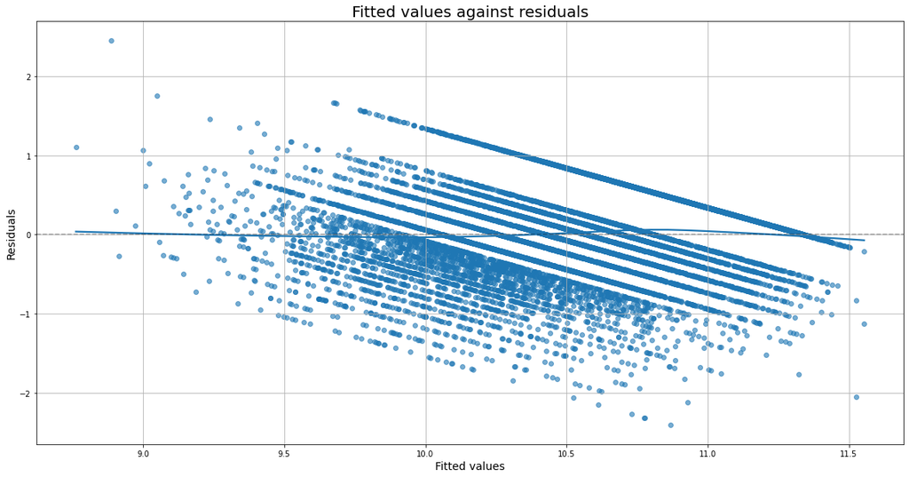

```python
residuals = mod3.resid
fitted =  mod3.fittedvalues

# Residual plot for reduced model with interaction terms
fig, ax= plt.subplots(figsize = (20,10))
sns.regplot(x=fitted, y=residuals, lowess=True, ax=ax, scatter_kws={'s': 35, 'alpha': .6})
ax.set_xlabel('Fitted values',  {'fontsize': 14})
ax.set_ylabel('Residuals', {'fontsize': 14})
ax.set_title('Fitted values against residuals', fontsize = 20)
plt.axhline(color='Black', alpha=0.3, linestyle='--')
plt.grid()
plt.show()
```

```python
print(f"SER (Model 3): {mod3.mse_resid**0.5 :0.3f}")
```

```
SER (Model 3): 0.512
```

## Print 10 first predicted earnings on the test data

```python
idx = [i for i in range(test_df.shape[0])]
earning_pred_df = pd.DataFrame(idx)
pred = np.exp(mod3.predict(test_df))
earning_pred_df.rename(columns = {0: 'ID'}, inplace=True)
earning_pred_df['earnings'] = pred
```

```python
earning_pred_df.head(10)
```

|  | ID | earnings |
| --- | --- | --- |
| 0 | 0 | 58307.492282 |
| 1 | 1 | 39551.841484 |
| 2 | 2 | 54948.254630 |
| 3 | 3 | 20970.113688 |
| 4 | 4 | 21688.672618 |
| 5 | 5 | 54391.807986 |
| 6 | 6 | 25258.115521 |
| 7 | 7 | 21921.083711 |
| 8 | 8 | 28825.514384 |
| 9 | 9 | 53425.346082 |

```python
earning_pred_df.to_csv("QBUS2810_2023S2_Group_06_predictions.csv", index=False)
```